# Bioinformatics at the DKFZ - Hands-on session step 12

Ian Dirk Fichtner

April 30, 2023

**Research question: Which transcription factor binding sites are better conserved in CpG island promoters?**

In steps 1-11 we formatted the GENCODE human genome promoter annotations and acquired the list of transcription factor binding sites (TFbs) that are present in promoters within CpG islands.

The output were two datasets in BED format, one containing the TFbs in CpG islands and the other containing the TFbs found in non CpG island regions.

To tackle the research question above, first, the dataset was loaded.

```r
library(tidyverse)

# Datasets
tfbs.cgi <- read.table("../../output/day1/tfbsCgiProm.bed", sep = "\t", col.names = c("chrom", "start", "stop", "name" , "score", "strand", "idk"))

tfbs.noncgi <- read.table("../../output/day1/tfbsNonCgiProm.bed", sep = "\t", col.names = c("chrom", "start", "stop", "name", "score", "strand", "idk"))
```

Then, it was preprocessed.

```r
chroms <- paste0("chr", append(1:22, c("X", "Y", "M")))

tfbs.cgi <- tfbs.cgi %>% filter(chrom %in% chroms)
tfbs.noncgi <- tfbs.noncgi %>% filter(chrom %in% chroms)

tfbs <- rbind.data.frame(tfbs.cgi %>% mutate(cpg = "CpG-island"), tfbs.noncgi %>% mutate(cpg = "Non-CpG-island"))
```

Finally, the research question was tackled and all proportion of TFbs found in CpG islands was calculated for every TF.

```r
tfbs.cpg.props <- tfbs %>%
    # Count TFbs by double grouping and format dataframe
    group_by(name, cpg) %>%
    summarise(count = n()) %>%
    pivot_wider(names_from = cpg, values_from = count, names_prefix = "counts_") %>%
    mutate(prop_CpG = `counts_CpG-island` / (`counts_CpG-island` + `counts_Non-CpG-island`)) %>%
    # Calulate proportions
    mutate(prop_nonCpG = `counts_Non-CpG-island` / (`counts_CpG-island` + `counts_Non-CpG-island`)) %>%
    arrange(desc(prop_CpG))

tfbs.cpg.props %>% head
```

```
## # A tibble: 6 × 5
## # Groups:   name [6]
##   name      `counts_CpG-island` `counts_Non-CpG-island` prop_CpG prop_nonCpG
##   <chr>                   <int>                   <int>    <dbl>       <dbl>
## 1 V$SP1_01                10728                   10081    0.516       0.484
## 2 V$SP1_Q6                27985                   26618    0.513       0.487
## 3 V$NFY_01                 7978                    7649    0.511       0.489
## 4 V$AP2_Q6                28902                   27875    0.509       0.491
## 5 V$NRF2_01               17541                   16944    0.509       0.491
## 6 V$NFY_Q6                16940                   16378    0.508       0.492
```

SP1 was found to be the TFbs found the most in CpG islands. This may be due to its role in cell differentiation, cell growth for which methylation regulation is crutial.

Additionally, the proportino of TFbs in CpG islands was calculated showing that more than half of the TFbs were found in CpG island regions. This is corroborated by the current literature (Vavouri and Lehner 2012).

```r
cpg.props <- tfbs %>% group_by(cpg) %>% summarise(count = n())

cpg.props
```

```
## # A tibble: 2 × 2
##   cpg               count
##   <chr>             <int>
## 1 CpG-island     15145110
## 2 Non-CpG-island 15130038
```

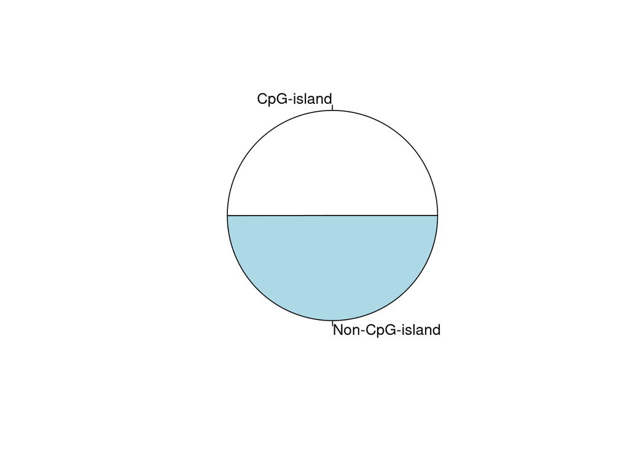

```r
pie(cpg.props$count, labels = cpg.props$cpg)
```